# Submission1

```python
import pandas as pd
import numpy as np
from scipy.stats import mode
```

Importing sales ,product and stores dataset

```python
data_sales = pd.read_csv('sales.csv',parse_dates=['date'])
```

```python
data_product_hierarchy = pd.read_csv('product_hierarchy.csv')
```

```python
data_store_cities = pd.read_csv('store_cities.csv')
```

```python
data_sales.head(5)
```

|  | product_id | store_id | date | sales | revenue | stock | price | promo_type_1 | promo_bin_1 | promo_type_2 | promo_bin_2 | promo_discount_2 | promo_discount_type_2 |
| --- | --- | --- | --- | --- | --- | --- | --- | --- | --- | --- | --- | --- | --- |
| 0 | P0001 | S0002 | 2017-01-02 | 0.0 | 0.00 | 8.0 | 6.25 | PR14 | NaN | PR03 | NaN | NaN | NaN |
| 1 | P0001 | S0012 | 2017-01-02 | 1.0 | 5.30 | 0.0 | 6.25 | PR14 | NaN | PR03 | NaN | NaN | NaN |
| 2 | P0001 | S0013 | 2017-01-02 | 2.0 | 10.59 | 0.0 | 6.25 | PR14 | NaN | PR03 | NaN | NaN | NaN |
| 3 | P0001 | S0023 | 2017-01-02 | 0.0 | 0.00 | 6.0 | 6.25 | PR14 | NaN | PR03 | NaN | NaN | NaN |
| 4 | P0001 | S0025 | 2017-01-02 | 0.0 | 0.00 | 1.0 | 6.25 | PR14 | NaN | PR03 | NaN | NaN | NaN |

```python
data_sales.isnull().sum()
```

```
product_id                      0
store_id                        0
date                            0
sales                     1190762
revenue                   1190762
stock                     1190762
price                      571981
promo_type_1                    0
promo_bin_1              16803149
promo_type_2                    0
promo_bin_2              19395757
promo_discount_2         19395757
promo_discount_type_2    19395757
dtype: int64
```

While checking null values in sales data, we can observe that sum of null values is same for revenue, sales and stock

```python
data_product_hierarchy.isnull().sum()
```

```
product_id         0
product_length    18
product_depth     16
product_width     16
cluster_id        50
hierarchy1_id      0
hierarchy2_id      0
hierarchy3_id      0
hierarchy4_id      0
hierarchy5_id      0
dtype: int64
```

```python
data_store_cities.isnull().sum()
```

```
store_id        0
storetype_id    0
store_size      0
city_id         0
dtype: int64
```

## Filling Nas for product hierarchy

```python
data_product_hierarchy['product_length'].fillna(data_product_hierarchy['product_length'].mean(),inplace = True)
data_product_hierarchy['product_depth'].fillna(data_product_hierarchy['product_depth'].mean(),inplace = True)
data_product_hierarchy['product_width'].fillna(data_product_hierarchy['product_width'].mean(),inplace = True)
data_product_hierarchy['cluster_id'].fillna(mode(data_product_hierarchy['cluster_id'])[0][0],inplace = True)
```

```python
data_product_hierarchy.isnull().sum()
```

```
product_id        0
product_length    0
product_depth     0
product_width     0
cluster_id        0
hierarchy1_id     0
hierarchy2_id     0
hierarchy3_id     0
hierarchy4_id     0
hierarchy5_id     0
dtype: int64
```

## Filling Nas for promos

```python
data_sales['promo_bin_1'].fillna(0,inplace= True)
data_sales['promo_bin_2'].fillna(0,inplace= True)
data_sales['promo_discount_2'].fillna(0,inplace= True)
data_sales['promo_discount_type_2'].fillna(0,inplace= True)
```

```python
data_sales.isna().sum()
```

```
product_id                     0
store_id                       0
date                           0
sales                    1190762
revenue                  1190762
stock                    1190762
price                     571981
promo_type_1                   0
promo_bin_1                    0
promo_type_2                   0
promo_bin_2                    0
promo_discount_2               0
promo_discount_type_2          0
dtype: int64
```

## Filling Nas for price

```python
dict_price = {}
for i, x in enumerate(data_sales['product_id']):
    if (x not in dict_price.keys() and not(np.isnan(data_sales['price'][i]))):
        dict_price[x]=data_sales['price'][i]
```

```python
data_sales.price = data_sales.price.fillna(data_sales.product_id.map(dict_price))
```

```python
data_sales.isna().sum()
```

```
product_id                     0
store_id                       0
date                           0
sales                    1190762
revenue                  1190762
stock                    1190762
price                      10444
promo_type_1                   0
promo_bin_1                    0
promo_type_2                   0
promo_bin_2                    0
promo_discount_2               0
promo_discount_type_2          0
dtype: int64
```

## Drop Nas for remaining Rows

```python
data_sales.dropna(inplace=True)
```

```python
data_sales.isna().sum()
```

```
product_id               0
store_id                 0
date                     0
sales                    0
revenue                  0
stock                    0
price                    0
promo_type_1             0
promo_bin_1              0
promo_type_2             0
promo_bin_2              0
promo_discount_2         0
promo_discount_type_2    0
dtype: int64
```

As we have observed that sum of null values is same for sales , revenue and stock through which we can interpret that if we are not having stock of that particular product in that store , thus which means there will be no sales ,, which will result in 0 revenue generation. So in order to handle the null values in these 3 cloumns we droped the rows having null value for sales , revenue and stock.

## Categorical to Numerical

#### promo_type_1

```python
data_sales['promo_type_1'].unique()
```

```
array(['PR14', 'PR05', 'PR10', 'PR03', 'PR06', 'PR07', 'PR12', 'PR17',
       'PR08', 'PR13', 'PR09', 'PR16', 'PR15', 'PR01', 'PR18', 'PR11',
       'PR04'], dtype=object)
```

```python
encode_dict_type_1 = {
    'PR01':1,
    'PR03':3,
    'PR04':4,
    'PR05':5,
    'PR06':6,
    'PR07':7,
    'PR08':8,
    'PR09':9,
    'PR10':10,
    'PR11':11,
    'PR12':12,
    'PR13':13,
    'PR14':14,
    'PR15':15,
    'PR16':16,
    'PR17':17,
    'PR18':18
}

data_sales['promo_type_1'].replace(encode_dict_type_1,inplace=True)
```

#### promo_bin_1

```python
data_sales['promo_bin_1'].unique()
```

[output not shown]

```python
encode_dict = {
    'verylow':1,
    'low':2,
    'moderate':3,
    'high':4,
    'veryhigh':5
}

data_sales['promo_bin_1'].replace(encode_dict,inplace=True)
```

#### promo_type_2

```python
data_sales['promo_type_2'].unique()
```

```
array(['PR03', 'PR02', 'PR01', 'PR04'], dtype=object)
```

```python
encode_dict_type_2 = {'PR01':1,
                     'PR02':2,
                     'PR03':3,
                     'PR04':4}

data_sales['promo_type_2'].replace(encode_dict_type_2,inplace=True)
```

#### promo_bin_2

```python
data_sales['promo_bin_2'].unique()
```

```
array([0, 'verylow', 'high', 'veryhigh'], dtype=object)
```

```python
encode_dict_bin_2 = {
    'verylow':1,
    'low':2,
    'high':3,
    'veryhigh':4
}


data_sales['promo_bin_2'].replace(encode_dict_bin_2,inplace=True)
```

#### promo_discount_type_2

```python
data_sales['promo_discount_type_2'].unique()
```

```
array([0, 'PR04', 'PR02', 'PR01', 'PR03'], dtype=object)
```

```python
encode_discount_type_2 = {'PR01':1,
                     'PR02':2,
                     'PR03':3,
                     'PR04':4}

data_sales['promo_discount_type_2'].replace(encode_discount_type_2,inplace=True)
```

```python
#Converting to weekly data

weekly_data = data_sales.groupby(['product_id','store_id']).resample('W', label='right', closed = 'right', on='date').sum().reset_index()
weekly_data
```

|  | product_id | store_id | date | sales | revenue | stock | price | promo_type_1 | promo_bin_1 | promo_type_2 | promo_bin_2 | promo_discount_2 | promo_discount_type_2 |
| --- | --- | --- | --- | --- | --- | --- | --- | --- | --- | --- | --- | --- | --- |
| 0 | P0001 | S0001 | 2017-02-12 | 2.0 | 11.02 | 0.0 | 13.0 | 28 | 0 | 6 | 0 | 0.0 | 0 |
| 1 | P0001 | S0001 | 2017-02-19 | 0.0 | 0.00 | 0.0 | 0.0 | 0 | 0 | 0 | 0 | 0.0 | 0 |
| 2 | P0001 | S0001 | 2017-02-26 | 1.0 | 5.51 | 0.0 | 6.5 | 14 | 0 | 3 | 0 | 0.0 | 0 |
| 3 | P0001 | S0001 | 2017-03-05 | 0.0 | 0.00 | 0.0 | 0.0 | 0 | 0 | 0 | 0 | 0.0 | 0 |
| 4 | P0001 | S0001 | 2017-03-12 | 0.0 | 0.00 | 0.0 | 0.0 | 0 | 0 | 0 | 0 | 0.0 | 0 |
| ... | ... | ... | ... | ... | ... | ... | ... | ... | ... | ... | ... | ... | ... |
| 2966720 | P0748 | S0142 | 2019-10-06 | 2.0 | 35.00 | 119.0 | 132.3 | 98 | 0 | 21 | 0 | 0.0 | 0 |
| 2966721 | P0748 | S0142 | 2019-10-13 | 0.0 | 0.00 | 112.0 | 132.3 | 98 | 0 | 21 | 0 | 0.0 | 0 |
| 2966722 | P0748 | S0142 | 2019-10-20 | 0.0 | 0.00 | 112.0 | 132.3 | 98 | 0 | 21 | 0 | 0.0 | 0 |
| 2966723 | P0748 | S0142 | 2019-10-27 | 0.0 | 0.00 | 112.0 | 132.3 | 98 | 0 | 21 | 0 | 0.0 | 0 |
| 2966724 | P0748 | S0142 | 2019-11-03 | 0.0 | 0.00 | 64.0 | 75.6 | 56 | 0 | 12 | 0 | 0.0 | 0 |

2966725 rows × 13 columns

In weekly_data , we can observe weekly sales of product in a particular store

```python
#Combining product_hierarchy features with sales

dict_length = dict(zip(data_product_hierarchy.product_id,data_product_hierarchy.product_length))
dict_depth = dict(zip(data_product_hierarchy.product_id,data_product_hierarchy.product_depth))
dict_width = dict(zip(data_product_hierarchy.product_id,data_product_hierarchy.product_width))

l = []
d = []
w = []
vol = []
for x in weekly_data['product_id']:
    l.append(dict_length[x])
    d.append(dict_depth[x])
    w.append(dict_width[x])
    vol.append(dict_length[x]*dict_depth[x]*dict_width[x])

weekly_data['product_length'] = l
weekly_data['product_depth'] = d
weekly_data['product_width'] = w
weekly_data['product_volume'] = vol
```

```python
#Combining product_hierarchy features with sales

dict_store_size = dict(zip(data_store_cities.store_id,data_store_cities.store_size))
dict_store_type = dict(zip(data_store_cities.store_id,data_store_cities.storetype_id))
dict_city = dict(zip(data_store_cities.store_id,data_store_cities.city_id))

size = []
store_type = []
city = []

for x in weekly_data['store_id']:
    size.append(dict_store_size[x])
    store_type.append(dict_store_type[x])
    city.append(dict_city[x])

weekly_data['store_size'] = size
weekly_data['store_type'] = store_type
weekly_data['store_city'] = city
```

```python
#Given Each Week an Index

weekly_data=weekly_data.sort_values(by='date')

t = []
k = 0
cnt = 0
for x in weekly_data['date']:
    if(k == x):
        t.append(cnt)
    else:
        cnt = cnt+1
        t.append(cnt)
        k = x

weekly_data['weekly_index'] = t
```

```python
#sorting like original data required

weekly_data = weekly_data.sort_values(by = ['product_id','store_id'])
```

```python
#Drop Unwanted Features

weekly_data = weekly_data.drop(['date','promo_bin_1','promo_type_2','promo_bin_2','promo_discount_2','promo_discount_type_2','promo_type_1'],axis = 1)
```

```python
# Encode Remaining Labels

from sklearn.preprocessing import LabelEncoder
le = LabelEncoder()
weekly_data['product_id'] = le.fit_transform(weekly_data['product_id'])
weekly_data['store_id'] = le.fit_transform(weekly_data['store_id'])
weekly_data['store_city'] = le.fit_transform(weekly_data['store_city'])
weekly_data['store_type'] = le.fit_transform(weekly_data['store_type'])
```

```python
weekly_data.isna().sum()
```

[output not shown]

```python
# Splitting Data for training and Testing

X_train = weekly_data[weekly_data.weekly_index < 148].drop(['sales','weekly_index'], axis=1)
y_train = weekly_data[weekly_data.weekly_index < 148]['sales']
X_test = weekly_data[weekly_data.weekly_index == 148].drop(['sales','weekly_index'], axis=1)
y_test =  weekly_data[weekly_data.weekly_index == 148]['sales']
```

```python
from xgboost import XGBRegressor
import time
from sklearn.metrics import mean_squared_error

ts = time.time()

xgb = XGBRegressor(
    )
xgb.fit(
    X_train,y_train,
    eval_metric="rmse",
    eval_set=[(X_train, y_train), (X_test, y_test)],
    verbose=True,
    early_stopping_rounds = 10
    )
print('Training took: {0}s'.format(time.time()-ts))
yhat_val_xgb = xgb.predict(X_test).clip(0, 20)
print('Valdation RMSE:', mean_squared_error(y_test, yhat_val_xgb)) #Valdation RMSE: 0.9409594444278176
yhat_test_xgb = xgb.predict(X_test).clip(0, 20)
```

```
Training took: 14.492287158966064s
Valdation RMSE: 8.508300381254958
```

```python
import pickle

filename = 'semi-finalized_model.sav'
pickle.dump(xgb, open(filename, 'wb'))
```

```python
MSE = np.square(np.subtract(y_test,yhat_val_xgb)).mean()
```

```python
MSE
```

```
8.50830038125587
```

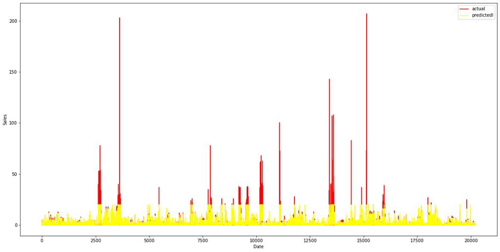

```python
import matplotlib.pyplot as plt
plt.figure(figsize=(20,10))
plt.plot(list(range(0,len(y_test))),y_test,color='red',label='actual')
plt.plot(list(range(0,len(y_test))),yhat_val_xgb,color='yellow',label="predictedl")
plt.xlabel("Date")
plt.ylabel("Sales")
leg = plt.legend()
plt.show()
```

Through the graph we can observe that , actual value graph that is represented in red are overlapping with predicted value graph represented in yellow.

**Important : actual value line above sales 50 are mostly outliers.

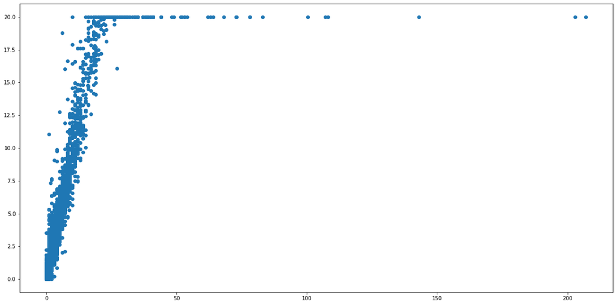

```python
plt.figure(figsize=(20,10))
plt.scatter(y_test,yhat_val_xgb)
```

```python
unique_pro_id = weekly_data['product_id'].unique()
unique_sto_id = weekly_data['store_id'].unique()
pro = []
sto = []
for x in unique_pro_id:
    for y in unique_sto_id:
        pro.append(x)
        sto.append(y)
df_final_sub = pd.DataFrame(data = list(zip(pro,sto)),columns=['pro_id','store_id'])
df_final_sub
```

[output not shown]

90000 rows × 2 columns